[O’Hara on GitHub](https://github.com/oharac)

# Map bycatch impacts

Compiled on Sun Sep 17 17:30:51 2023 by ohara

```r
knitr::opts_chunk$set(echo = TRUE, message = FALSE, warning = FALSE,
                      fig.height = 4, fig.width = 7)

library(terra)
library(oharac)
library(data.table)
library(tidyverse)
library(here)
source(here('common_fxns.R'))
```

# 1 Summary

Because of large differences in bycatch potential depending on where in the water column a creature exists, exposure is not identical across all spp in a cell. The bycatch stressor script (`_setup/stressors/3_process_fishing_bycatch.Rmd`) generates a separate stressor map for benthic vs pelagic/midwater species:

- `_data/stressors_bc/bycatch_pelagic_2017.tif`
- `_data/stressors_bc/bycatch_benthic_2017.tif`

The current script assigns each species as exposed to either benthic, pelagic, or both (benthopelagic, reef) bycatch layers. each species, multiplies by the spp vulnerability (primarily driven by adaptive capacity) to calculate impact. These spp-level impacts are then aggregated by:

- unweighted mean impact in each cell across all spp present
- unweighted mean impact in each cell across only spp included in functional vulnerability calculations (for better comparison against FV weighting)
- functional-vulnerability-weighted mean impact in each cell.

# 2 Data

- Vulnerability data from Ecosphere trait-based vulnerability
- Stressor data from the script noted above - based on Watson 2017.

# 3 Methods

## 3.1 Set up spp map source and vulnerability data

Filter to just bycatch stressor.

```r
spp_info_df <- get_spp_info() %>%
  rename(vulnerability = stressor) %>%
  filter(vulnerability == 'bycatch') %>%
  mutate(wcol = ifelse(wcol %in% c('bp', 'rf'), 'both', wcol))

spp_info_df %>%
  group_by(taxon) %>%
  summarize(nspp = n_distinct(species))
```

```
## # A tibble: 12 × 2
##    taxon                 nspp
##    <chr>                <int>
##  1 cephalopods             15
##  2 corals                  44
##  3 crustacea_arthropods   166
##  4 echinoderms            126
##  5 elasmobranchs           28
##  6 fish                   598
##  7 marine_mammals          38
##  8 molluscs                95
##  9 polychaetes            133
## 10 reptiles                 1
## 11 seabirds                65
## 12 sponges                 17
```

Read in bycatch stressor maps, and create a dataframe of the results. Assign species to one of three bins based on water column position trait. Benthopelagic and reef associated spp will take an average of the two bycatch stressor maps.

```r
benth_rast <- rast(here('_data/stressors_bc/bycatch_benthic_2017.tif'))
pelag_rast <- rast(here('_data/stressors_bc/bycatch_pelagic_2017.tif'))
bp_rast <- (benth_rast + pelag_rast) / 2

bycatch_cells_df <- data.frame(ben = as.vector(values(benth_rast)),
                               pel = as.vector(values(pelag_rast)),
                               both    = as.vector(values(bp_rast)),
                               cell_id = 1:ncell(benth_rast)) %>%
  filter(!is.na(ben) | !is.na(pel)) %>%
  pivot_longer(names_to = 'wcol', values_to = 'bycatch', cols = -cell_id)
```

## 3.2 Impacts by unweighted mean vulnerability

### 3.2.1 Calculate mean bycatch impacts per taxon

Loop over each taxon; pull all rangemaps for that taxon. For each species in the taxon, multiply bycatch stressor map by the spp vulnerability to identify impact map for that species. Summarize across the entire taxon to mean, sd, and nspp.

```r
taxa <- spp_info_df$taxon %>% unique() %>% sort()

out_stem <- here_anx('impact_maps_by_taxon/impacts_tx_bycatch',
                     'imp_unwt_bycatch_%s_%s.tif')
### zxcv <- list.files(dirname(out_stem), pattern = 'imp_unwt_bycatch', full.names = TRUE)
### unlink(zxcv)
for(t in taxa) {
  ### t <- taxa[1]
  tx_vuln_df <- spp_info_df %>%
    filter(taxon == t) %>%
    select(species, v_score, wcol) %>%
    distinct()
  tx_maps_df <- spp_info_df %>%
    filter(taxon == t) %>%
    select(species, map_f) %>%
    distinct()

  outf_mean <- sprintf(out_stem, t, 'mean')
  outf_sdev <- sprintf(out_stem, t, 'sdev')
  outf_nspp <- sprintf(out_stem, t, 'nspp')
  if(all(file.exists(outf_mean, outf_sdev))) {
    message('Rasters exist for taxon ', t, ' for bycatch stressor... skipping!')
    next()
  }
  ### read in all bycatch stressor maps for this taxon -
  message('Loading bycatch stress maps for taxon ', t, '...')
  tx_maps <- collect_spp_rangemaps(tx_maps_df$species, tx_maps_df$map_f)

  message('Taxon ', t, ' bycatch stressor dataframe: ', nrow(tx_maps),
          ' cell observations for ', nrow(tx_maps_df), ' species...')

  message('Processing mean/sd vulnerability by species in taxon ', t,
          ' to bycatch stressor...')

  ### because failures might occur with summarizing a huge dataset,
  ### let's break this into chunks by cell_id
  chunk_size <- 500000
  n_cells  <- rast(here('_spatial/ocean_bc_1km.tif')) %>% ncell()
  n_chunks <- ceiling(n_cells / chunk_size)
  n_cores  <- ceiling(16 * 1e6 / nrow(tx_maps))
  # system.time({
  result_list <- parallel::mclapply(1:n_chunks, mc.cores = n_cores,
       FUN = function(n) { ### n <- 6
         cell_id_min <- as.integer((n - 1) * chunk_size + 1)
         cell_id_max <- as.integer(n * chunk_size)
         message('Summarizing bycatch stressor on taxon ', t,
                 ': cells ', cell_id_min, ' - ', cell_id_max, '...')

         chunk_sum <- tx_maps %>%
           filter(between(cell_id, cell_id_min, cell_id_max)) %>%
           oharac::dt_join(tx_vuln_df, by = 'species', type = 'left') %>%
           oharac::dt_join(bycatch_cells_df,
                           by = c('cell_id', 'wcol'), type = 'left') %>%
           data.table() %>%
           .[ , bycatch := ifelse(is.na(bycatch), 0, bycatch)] %>%
           .[ , impact  := v_score * bycatch] %>%
           .[ , .(impact_mean = mean(impact),
                  impact_sd   = sd(impact),
                  n_spp       = length(unique(species))),
              by = 'cell_id']
         })

  if(check_tryerror(result_list)) {
    stop('Something went wrong with calculations for taxon ', t, '!')
  }

  message('Binding results for taxon ', t, '...')
  result_df <- result_list %>%
    data.table::rbindlist() %>%
    filter(!is.na(cell_id))

  message('Creating and saving rasters for taxon ', t, '...')
  rast_mean <- map_to_bc(result_df, which = 'impact_mean')
  rast_sd   <- map_to_bc(result_df, which = 'impact_sd')
  rast_nspp <- map_to_bc(result_df, which = 'n_spp')

  writeRaster(rast_mean, outf_mean, overwrite = TRUE)
  writeRaster(rast_sd,   outf_sdev, overwrite = TRUE)
  writeRaster(rast_nspp, outf_nspp, overwrite = TRUE)
}
```

### 3.2.2 Summarize mean bycatch impacts across all taxa

Combine taxon-level maps using nspp-weighted mean and pooled variance. Pooled var functions written and tested for script 2a.

```r
combine_taxa_maps <- function(tx_bycatch_map_df) {

  mean_fs <- tx_bycatch_map_df %>% filter(p == 'mean') %>% .$f
  sdev_fs <- tx_bycatch_map_df %>% filter(p == 'sdev') %>% .$f
  nspp_fs <- tx_bycatch_map_df %>% filter(p == 'nspp') %>% .$f
  taxa <- tx_bycatch_map_df$t %>% unique()

  message('... loading mean maps across taxa for bycatch...')
  mean_df <- parallel::mclapply(mean_fs, mc.cores = 24, FUN = r_to_df) %>%
    setNames(taxa) %>%
    data.table::rbindlist(idcol = 'taxon') %>%
    rename(imp_mean = val)

  message('... loading std dev maps across taxa for bycatch...')
  sdev_df <- parallel::mclapply(sdev_fs, mc.cores = 24, FUN = r_to_df) %>%
    setNames(taxa) %>%
    data.table::rbindlist(idcol = 'taxon') %>%
    rename(imp_sdev = val)

  message('... loading nspp maps across taxa for bycatch...')
  nspp_df <- parallel::mclapply(nspp_fs, mc.cores = 24, FUN = r_to_df) %>%
    setNames(taxa) %>%
    data.table::rbindlist(idcol = 'taxon') %>%
    rename(imp_nspp = val)

  message('... joining mean, sd, nspp into big-ass dataframe for bycatch...')
  big_df <- mean_df %>%
    oharac::dt_join(sdev_df, by = c('taxon', 'cell_id'), type = 'full') %>%
    oharac::dt_join(nspp_df, by = c('taxon', 'cell_id'), type = 'full')

  return(big_df)
}

process_mean_rasts <- function(big_df) {
  ### Set up for parallel processing
  cell_id_vec <- big_df$cell_id %>% unique()
  n_gps <- 25
  gp_vec <- rep(1:n_gps, length.out = length(cell_id_vec))

  ### perform parallel processing
  spp_mean_list <- parallel::mclapply(
    X = 1:n_gps, mc.cores = 25,
    FUN = function(gp) { ### gp <- 1
      gp_cells <- cell_id_vec[gp_vec == gp]
      message('...processing ', length(gp_cells), ' cells in group ', gp, '...')
      gp_out <- big_df %>%
        filter(cell_id %in% gp_cells) %>%
        group_by(cell_id) %>%
        summarize(imp_mean = (sum(imp_mean * imp_nspp) / sum(imp_nspp)))
    })

  ### gather results
  spp_mean_df <- data.table::rbindlist(spp_mean_list)
  return(spp_mean_df)
}

process_sdev_rasts <- function(big_df) {
  ### Set up for parallel processing
  cell_id_vec <- big_df$cell_id %>% unique()
  n_gps <- 100
  gp_vec <- rep(1:n_gps, length.out = length(cell_id_vec))

  ### perform parallel processing
  all_spp_sdev_list <- parallel::mclapply(
    X = 1:n_gps, mc.cores = 20,
    FUN = function(gp) { ### gp <- round(n_gps / 2)
      gp_cells <- cell_id_vec[gp_vec == gp]
      message('...processing ', length(gp_cells), ' cells in group ', gp, ' of ', n_gps, '...')
      # system.time({
        gp_sdev_out <- big_df %>%
          filter(cell_id %in% gp_cells) %>%
          group_by(cell_id) %>%
          summarize(imp_var = iterated_pooled_var(imp_mean, imp_sdev, imp_nspp),
                    imp_sdev = sqrt(imp_var))
      # })
      return(gp_sdev_out)
    })

  ### gather results
  all_spp_sdev <- data.table::rbindlist(all_spp_sdev_list)
  return(all_spp_sdev)
}

r_to_df <- function(f) {
  r <- terra::rast(f)
  df <- data.frame(val = as.vector(values(r)),
                   cell_id = 1:ncell(r)) %>%
    filter(!is.na(val))
  return(df)
}
```

```r
tx_bycatch_map_df <- data.frame(f = list.files(dirname(out_stem),
                                               pattern = 'imp_unwt_bycatch',
                                               full.names = TRUE)) %>%
  mutate(t = str_extract(basename(f), paste0(taxa, collapse = '|')),
         p = str_extract(basename(f), '_mean|_sdev|_nspp') %>% str_remove('_'))

impact_map_stem <- here_anx('_output/impact_maps/impact_maps_species',
                        'impact_spp_bycatch_%s.tif')
  ### %s is parameter (mean, sd, nspp)

### check if total stressor maps are complete
impact_f_mean <- sprintf(impact_map_stem, 'mean')
impact_f_sdev <- sprintf(impact_map_stem, 'sdev')

if(!all(file.exists(impact_f_mean, impact_f_sdev))) {
  ### Combine mean, sdev, and nspp maps by taxon into one big dataframe
  message('Processing mean, sd, nspp maps across all species for bycatch stressor...')
  big_df <- combine_taxa_maps(tx_bycatch_map_df)
}

### Process mean raster across taxa
if(!file.exists(impact_f_mean)) {
  message('... summarizing mean impact map across all taxa...')

  spp_mean <- process_mean_rasts(big_df)
  rast_mean <- map_to_bc(spp_mean, which = 'imp_mean')

  message('Writing out mean raster: \n  ',
          str_replace(impact_f_mean, '/home/ohara/github/', 'GitHub:'))

  writeRaster(rast_mean, impact_f_mean, overwrite = TRUE)
}

### Process standard deviation raster across taxa using pooled var
if(!file.exists(impact_f_sdev)) {
  message('... summarizing standard deviation impact map across all taxa...')
  ### break this into smaller chunks and parallelize over those?

  spp_sdev <- process_sdev_rasts(big_df)
  rast_sdev <- map_to_bc(spp_sdev, which = 'imp_sdev')

  message('Writing out std dev raster: \n  ',
          str_replace(impact_f_sdev, '/home/ohara/github/', 'GitHub:'))

  writeRaster(rast_sdev, impact_f_sdev, overwrite = TRUE)
}

### check that nspp adds up correctly
# spp_nspp <- big_df %>% group_by(cell_id) %>% summarize(nspp = sum(imp_nspp))
# rast_nspp <- map_to_bc(spp_nspp, which = 'nspp')
# main_nspp <- rast(here('_output/nspp_maps/species_richness'))
# x <- as.vector(values(rast_nspp)); y <- as.vector(values(main_nspp))
# match <- (is.na(x) & is.na(y)) | x == y
# all(match)
```

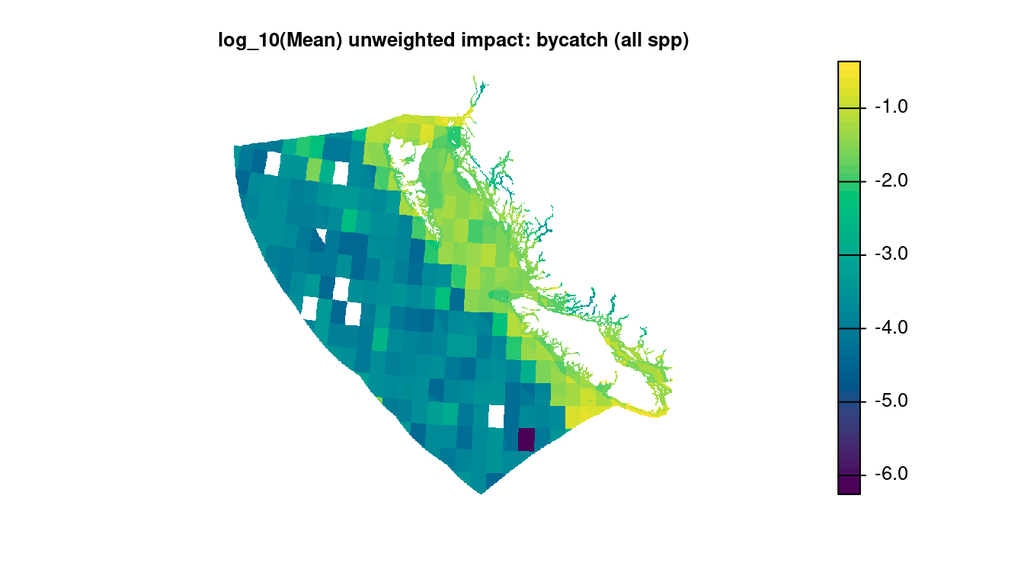

```r
mean_rast_spp <- rast(impact_f_mean)
sdev_rast_spp <- rast(impact_f_sdev)
cv_rast_spp <- sdev_rast_spp / mean_rast_spp

map_cols <- hcl.colors(n = 50)

plot(log10(mean_rast_spp), col = map_cols,
     main = 'log_10(Mean) unweighted impact: bycatch (all spp)',
     legend = TRUE, axes = FALSE)
```

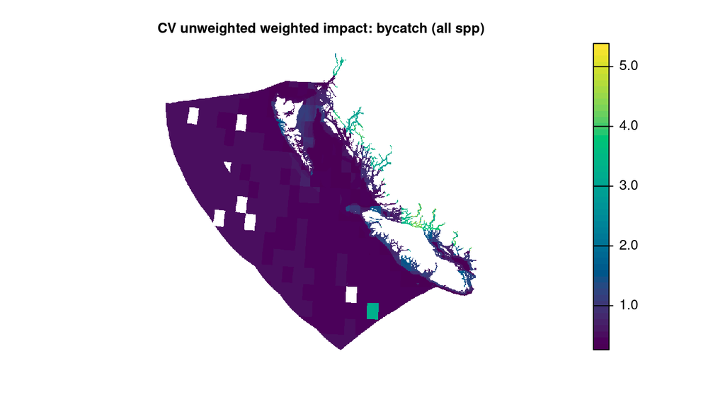

```r
plot(cv_rast_spp, col = map_cols,
     main = 'CV unweighted weighted impact: bycatch (all spp)',
     legend = TRUE, axes = FALSE)
```

## 3.3 Impacts by FV-weighted mean vulnerability

Here we will rely on similar code to that used in script 3a_map_funct_entity_vulnerability.Rmd.

### 3.3.1 Tidy the loop

Because this is a complex process, let’s tidy the big `for` loop by breaking out key code as functions.

- `read_truncated_rangemap`: read in all range maps, truncating each one to just those cells in the current chunk.
- `calc_fv`: Calculate the functional vulnerability for a given functional entity based on the number of spp present.
- `calc_spp_cell_fv`: For each cell, identify all FEs and calculate the FV of each. Because grouping by large numbers of groups (e.g, 100000 cells and multiple FEs), for crash-avoidance, this is parallelized.
- `bind_maps_list`: for a list of truncated species maps, clean out NULL results and bind rows, keeping cell ID and species name.
- `calc_chunk_str_sum`: for a dataframe of truncated species maps

```r
read_truncated_rangemap <- function(f, chunk_start, chunk_end) {
  if(file.exists(f)) {
    df <- data.table::fread(f) %>%
      filter(between(cell_id, chunk_start, chunk_end)) %>%
      mutate(map_f = f)
    ### filter for presence and prob as needed
    if(str_detect(basename(f), 'am')) {
      df <- df %>%
        filter(prob >= .5) %>%
        select(-prob)
    } else {
      df <- df %>%
        filter(presence != 5) %>%
        select(-presence)
    }
  } else {
    df <- data.frame()
  }
  if(nrow(df) == 0) {
    return(NULL)
  } else {
    return(df)
  }
}

bind_maps_list <- function(chunk_maps_list, spp_for_calc) {
  ### NOTE: for some reason, the bind_rows() in here sometimes causes
  ### unrecoverable errors when knitting, but seems OK when running chunks
  ### individually... try subbing with data.table::rbindlist
  if(check_tryerror(chunk_maps_list)) {
    stop('Try-error detected in bind_maps_list()!')
  }
  chunk_maps_raw <- chunk_maps_list %>%
    ### drop NULL instances (no spp cells - helps keep things from crashing)
    purrr::compact() %>%
    data.table::rbindlist()

  spp_for_calc <- spp_for_calc %>%
    select(species, map_f) %>%
    distinct()

  if(nrow(chunk_maps_raw) > 0) {
    ### if no spp-cell data for this chunk, skip bind and return 0-length df
    chunk_maps_raw <- chunk_maps_raw %>%
      oharac::dt_join(spp_for_calc, by = 'map_f', type = 'left') %>%
      select(-map_f) %>%
      distinct()
  }
  return(chunk_maps_raw)
}

calc_chunk_str_sum <- function(chunk_maps, spp_for_calc) {
  chunk_spp_imp <- spp_for_calc %>%
    filter(species %in% chunk_maps$species) %>%
    select(species, v_score, wcol) %>%
    distinct()

  cell_id_df <- data.frame(cell_id = chunk_maps$cell_id %>% unique()) %>%
    mutate(cell_gp = rep(1:100, length.out = n()))
  cell_gps <- cell_id_df$cell_gp %>% unique()

  chunk_spp_str_imp <- chunk_maps %>%
    oharac::dt_join(chunk_spp_imp, by = 'species', type = 'inner')  %>%
    oharac::dt_join(bycatch_cells_df, by = c('cell_id', 'wcol'), type = 'left')

  ### parallelize for speed! balance vectorization with parallel to reduce crashing...
  chunk_imp_list <- parallel::mclapply(cell_gps, mc.cores = 25,
          FUN = function(gp) { ### gp <- 41
            cell_ids <- cell_id_df %>%
              filter(cell_gp == gp) %>%
              .$cell_id
            df <- chunk_spp_str_imp %>%
              filter(cell_id %in% cell_ids) %>%
              data.table() %>%
              .[ , impact := v_score * bycatch] %>%
              .[ , .(impact_mean = mean(impact), #,
                     impact_sd   = sd(impact), #,
                     ### super-tiny fv (~ 1e-20) result in Inf var
                     fv = first(fv) %>% round(10)),
                 by = .(cell_id, fe_id)] %>%
              .[ , .(n_fe = length(unique(fe_id)),
                     fv_wt_mean_impact = Hmisc::wtd.mean(impact_mean, weights = fv),
                     fv_wt_sd_impact   = sqrt(Hmisc::wtd.var(impact_mean, weights = fv))),
                 by = 'cell_id']
          })
  if(check_tryerror(chunk_imp_list)) {
    stop('Try-errors detected in calc_chunk_str_sum()')
  }
  chunk_imp_sum_df <- data.table::rbindlist(chunk_imp_list)
  return(chunk_imp_sum_df)
}
```

```r
n_cells <- rast(here('_spatial/ocean_bc_1km.tif')) %>% ncell()
chunk_size <- 100000
n_chunks <- ceiling(n_cells / chunk_size)

spp_fe <- spp_info_df %>%
  select(species, fe_id) %>%
  distinct()

tmp_stem_fe <- here_anx('impact_maps_by_taxon/impacts_tx_bycatch',
                        'imp_fvwt_summary_chunk_%s_to_%s_bycatch.csv')
### zxcv <- list.files(dirname(tmp_stem_fe), pattern = 'imp_fvwt_summary_chunk', full.names = TRUE)
### unlink(zxcv)

for(chunk_i in 1:n_chunks) {
  ### chunk_i <- 3
  ### chunk_i <- 64

  ### Set up chunk start and end and filenames; check whether maps
  ### all stressors for this chunk...
  chunk_start <- (chunk_i - 1) * chunk_size + 1
  chunk_end   <- as.integer(chunk_i * chunk_size)
  chunk_text <- sprintf('chunk %s of %s (cells %s to %s)',
                        chunk_i, n_chunks, chunk_start, chunk_end)

  ### check if all chunk-stressor maps are complete
  tmp_bycatch_fe <- sprintf(tmp_stem_fe, chunk_start, chunk_end)
  if(file.exists(tmp_bycatch_fe)) {
    message('Temp csv exists for ', chunk_text, ' for stressor bycatch... skipping!')
    next()
  }

  ### Some chunk maps remain, so continue:
  ### Load species bycatch pressure maps for this chunk, then clean and bind:
  message('Loading ', nrow(spp_info_df), ' rangemaps cropped for ', chunk_text,  '...')

  chunk_maps_list <- parallel::mclapply(spp_info_df$map_f, mc.cores = 40,
                                        ### f <- mapfile_fe_df$map_f[1]
                                        FUN = read_truncated_rangemap,
                                        chunk_start = chunk_start, chunk_end = chunk_end)

  chunk_maps_raw <- bind_maps_list(chunk_maps_list, spp_info_df)

  ### if result includes no cells, write out empty chunk files
  if(nrow(chunk_maps_raw) == 0) {
    message('No species X cells found for ', chunk_text,
            '... writing out empty data.frame...')
    write_csv(data.frame(), tmp_bycatch_fe)
    next()
  }

  ### OK, now we have species and cells for this chunk.  Calculate functional vulnerability!
  message('... Calculating functional vulnerability metrics for ', nrow(chunk_maps_raw),
          ' spp-cells in ', chunk_text, '...')
  chunk_maps <- chunk_maps_raw %>%
    calc_spp_cell_fe(spp_fe)

  message('... In ', chunk_text,  ' rangemap dataframe: \n      ', nrow(chunk_maps),
          ' cell observations for ', n_distinct(chunk_maps$species), ' species across ',
          n_distinct(chunk_maps$fe_id), ' functional entities...')


  message('... Processing mean/sd vuln in ', chunk_text, ' to stressor: bycatch...')
  chunk_str_sum <- calc_chunk_str_sum(chunk_maps, spp_for_calc = spp_info_df)

  write_csv(chunk_str_sum, tmp_bycatch_fe)
}
```

### 3.3.2 Aggregate chunk vulnerability maps to global map

For each stressor, pull in all chunk dataframes, assemble into dataframe, and save out as rasters.

```r
chunk_files <- list.files(dirname(tmp_stem_fe),
                          pattern = 'imp_fvwt_summary_chunk', full.names = TRUE)

rast_fe_out_stem <- here_anx('_output/impact_maps/impact_maps_funct_entity',
                         'impact_fe_bycatch_%s.tif')

rast_mean_imp_fe_f <- sprintf(rast_fe_out_stem, 'mean')
rast_sdev_imp_fe_f <- sprintf(rast_fe_out_stem, 'sdev')

if(any(!file.exists(rast_mean_imp_fe_f, rast_sdev_imp_fe_f))) {
  message('Gathering impact chunk maps for bycatch...')

  impact_map_df <- parallel::mclapply(chunk_files, mc.cores = 33,
                                      FUN = data.table::fread) %>%
    bind_rows()

  message('Converting impact maps to rasters for bycatch...')
  mean_rast_fe <- map_to_bc(impact_map_df, by = 'cell_id', which = 'fv_wt_mean_impact')
  sdev_rast_fe <- map_to_bc(impact_map_df, by = 'cell_id', which = 'fv_wt_sd_impact')

  message('Writing impact rasters for bycatch...')
  writeRaster(mean_rast_fe, rast_mean_imp_fe_f, overwrite = TRUE)
  writeRaster(sdev_rast_fe, rast_sdev_imp_fe_f, overwrite = TRUE)

  ### check that n_fe adds up correctly
  # n_fe <- impact_map_df %>% data.table() %>% .[ , n_fe := sum(n_fe), by = 'cell_id']
  # rast_n_fe <- map_to_bc(n_fe, which = 'n_fe')
  # main_n_fe <- rast(here('_output/nspp_maps/funct_entity_richness'))
  # x <- as.vector(values(rast_n_fe)); y <- as.vector(values(main_n_fe))
  # match <- (is.na(x) & is.na(y)) | x == y
  # all(match)
}
```

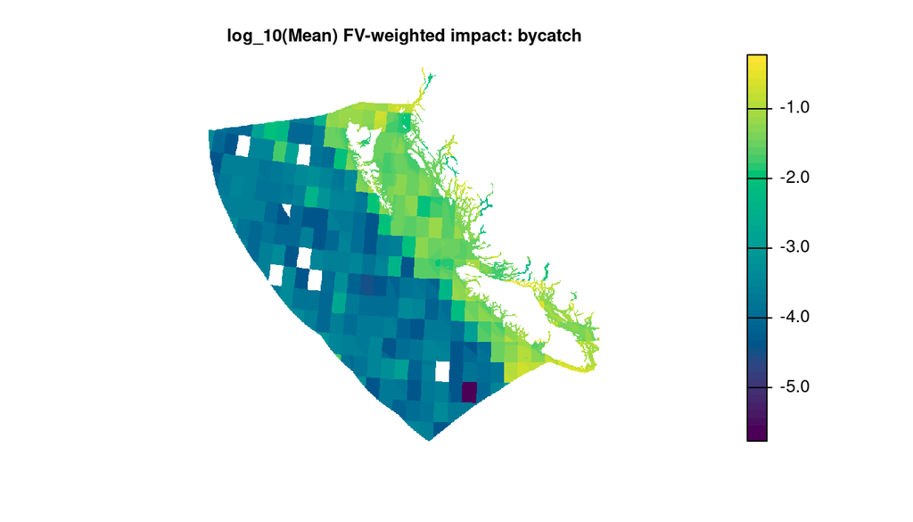

```r
mean_rast_fe <- rast(rast_mean_imp_fe_f)
sdev_rast_fe <- rast(rast_sdev_imp_fe_f)
cv_rast_fe <- sdev_rast_fe / mean_rast_fe

map_cols <- hcl.colors(n = 50)

plot(log10(mean_rast_fe), col = map_cols,
     main = 'log_10(Mean) FV-weighted impact: bycatch',
     legend = TRUE, axes = FALSE)
```

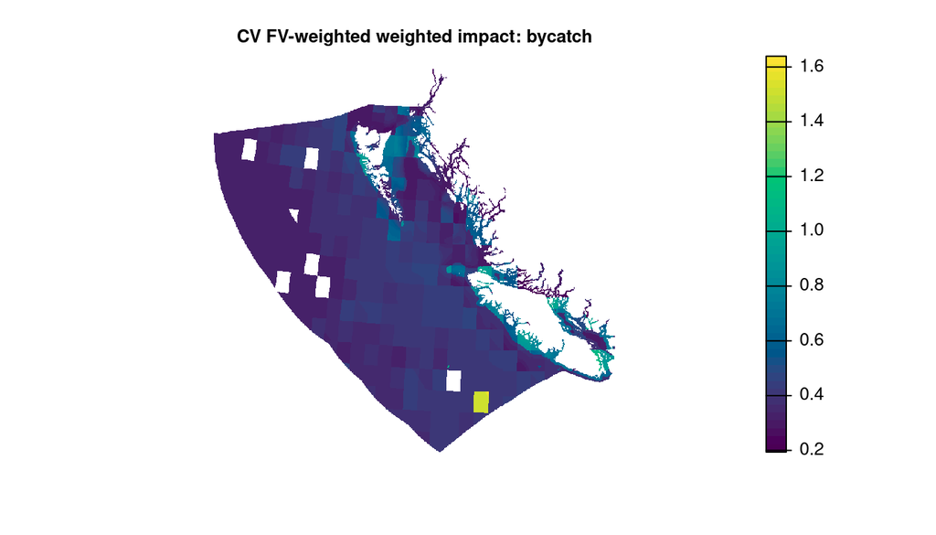

```r
plot(cv_rast_fe, col = map_cols,
     main = 'CV FV-weighted weighted impact: bycatch',
     legend = TRUE, axes = FALSE)
```

## 3.4 Difference maps

Loop over several focal stressors. For each stressor, read in the maps of unweighted mean impact $\bar x$ and fv-weighted mean impact $\bar x_{FV}$. Calculate difference as proportional difference in FV-weighted mean relative to unweighted mean impact:
$$diff = (\bar x_{FV} - \bar x) / \bar
x$$

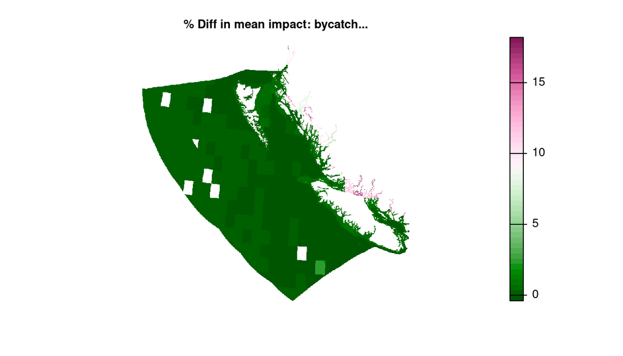

```r
squish_rast <- function(r, qtile = .999) {
  r_vals <- values(r); r_vals <- r_vals[!is.na(r_vals)]
  r_zlim <- max(abs(quantile(r_vals, 1 - qtile)), abs(quantile(r_vals, qtile)))
  values(r)[values(r) > r_zlim] <- r_zlim
  values(r)[values(r) < -r_zlim] <- -r_zlim

  return(list(r = r, zlim = r_zlim))
}

### Set up rasters; trim extreme values
mean_diff_rast <- (mean_rast_fe - mean_rast_spp) / mean_rast_spp
mean_diff_squished <- squish_rast(mean_diff_rast, qtile = .999)
# cv_diff_rast <- (cv_rast_fe - cv_rast_spp) / cv_rast_spp
# cv_r_sq <- squish_rast(cv_diff_rast, qtile = .999)

m_d_mask_0.10 <- m_d_mask_0.25 <- mean_diff_squished$r
values(m_d_mask_0.10)[values(mean_rast_spp) < .10 | values(mean_rast_fe) < .10] <- NA
values(m_d_mask_0.25)[values(mean_rast_spp) < .25 | values(mean_rast_fe) < .25] <- NA

message('Plotting difference maps for bycatch...')

### Set up plot for diverging palette, and symmetric z limits around zero
map_cols <- hcl.colors(palette = 'Red-Green', n = 50, rev = TRUE)

r <- mean_diff_squished$r; z = c(-mean_diff_squished$zlim, mean_diff_squished$zlim)

plot(mean_diff_squished$r, col = map_cols,
     main = '% Diff in mean impact: bycatch...',
     zlim = z,
     legend = TRUE, axes = FALSE)
```

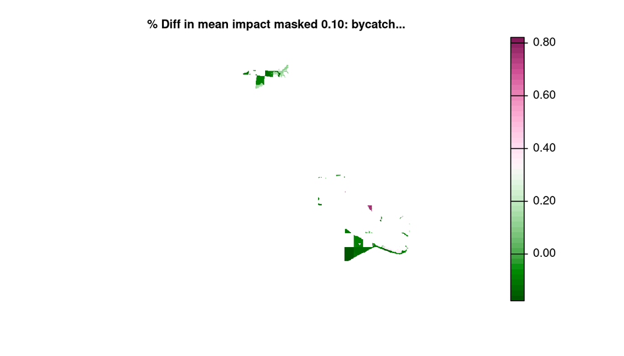

```r
plot(m_d_mask_0.10, col = map_cols,
     main = '% Diff in mean impact masked 0.10: bycatch...',
     zlim = z,
     legend = TRUE, axes = FALSE)
```

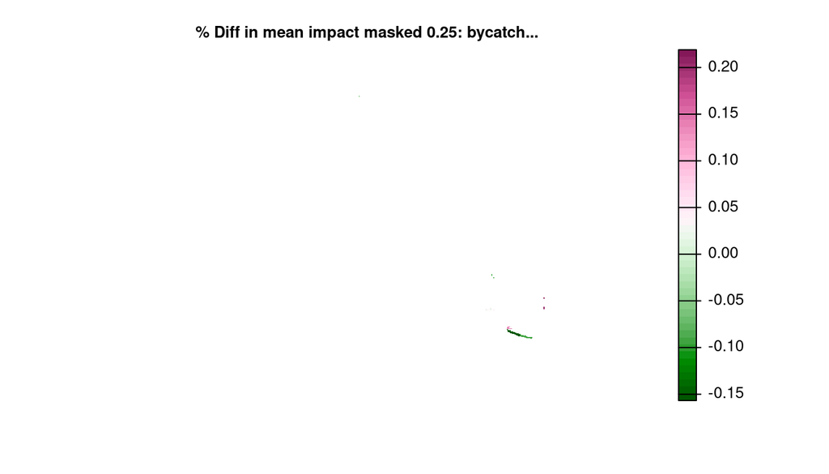

```r
plot(m_d_mask_0.25, col = map_cols,
     main = '% Diff in mean impact masked 0.25: bycatch...',
     zlim = z,
     legend = TRUE, axes = FALSE)
```